# DeconvTest: simulation framework for quantifying errors and selecting optimal parameters of image deconvolution

# Deconvolving microscopy images with the help of DeconvTest

Importantly, DeconvTest can help to deconvolve real microscopy images by identifying the optimal deconvolution parameters. For this, we first need to identify the properties of our microscopy images such as voxel size, PSF size, noise SNR, and the size of the features of interest. We then generate synthetic data with the same properties and deconvolve them with different settings using DeconvTest, which allows us to identify the deconvolution settings that result in the lowest errors. Finally, we can apply the identified algorithm and settings to reconstruct real microscopy images either within DeconvTest or using other software.

## Identifying image properties

Thus, as the first step, we need to determine important image properties. Many of these can be identified using ImageJ.

### Voxel size

To check the voxel size of the image, go to Image -> Properties:

￼

[figure not shown]

### Size of the features of interest

To measure the size of the features of interest, e.g. cells, select the line tool and measure the size of a few objects. The length of the line will be displayed on the main panel of ImageJ using the same units that are set in the Image Properties:

￼

[figure not shown]

￼

[figure not shown]

### Signal-to-noise ratio

To measure the signal-to-noise ratio (SNR), run Analyze -> Set Measurements and select Standard deviation and Mean gray value to be computed.

￼

[figure not shown]

After that, select a few regions (e.g. with the elliptical selection tool) that are relatively bright but not over-saturated and run Analyze -> Measure.

￼

[figure not shown]

￼

[figure not shown]

Divide the computed Mean gray value by the standard deviation to estimate SNR for each region. Take the smallest value for a conservative estimate.

### Size of the point spread function

To estimate the size of the PSF, we need a PSF image, which can be either generated theoretically (e.g. using [Huygens](https://svi.nl/TheoreticalPsf) or [ImageJ/Fiji](http://bigwww.epfl.ch/algorithms/psfgenerator/)) or measured by imaging fluorescent beads.

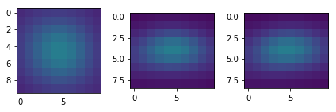

```python
psf = PSF(filename='data/microscopy/real_data/psf_measured.tif')
psf.show_2d_projections()
```

DeconvTest provides tools to measure the size of the PSF by approximating is with a Gaussian function:

```python
sigmas = psf.measure_psf_sigma()
sigmas
```

```
array([1.85119242, 3.34716592, 3.35760041])
```

The measured values are in pixels and need to be multiplied by the corresponding voxel size to obtain the values in micrometers:

```python
sigmas = sigmas * np.array([3, 0.415, 0.415])
sigmas
```

```
array([5.55357725, 1.38907386, 1.39340417])
```

The aspect ratio of the PSF can be computed by dividing the standard deviation in z (the first value) by the standard deviation in x or y (the second or third value):

```python
aspect = sigmas[0] / sigmas[1]
aspect
```

```
3.9980431713697064
```

## Running DeconvTest workflow with identified image properties

Now, when the microscopy image properties have been identified, we can adjust the DeconvTest configuration file to generate synthetic images with the same properties and deconvolve them with desired algorithms and parameters:

```python
config = pd.Series({'simulation_folder': 'data/microscopy/',
                    'simulation_steps': ['generate_cells', 'generate_psfs',
                                         'convolve', 'resize', 'add_noise', 'deconvolve', 'accuracy'],
                    'max_threads': 1,
                    'number_of_cells': 10,
                    'size_mean_and_std': (15, 3),
                    'input_voxel_size': 0.1,
                    'psf_sigmas': 1.4,
                    'psf_aspect_ratios': 4,
                    'voxel_sizes_for_resizing': [[3, 0.45, 0.45]],
                    'noise_kind': ['poisson'],
                    'snr': 2,
                    'deconvolution_algorithm': ['deconvolution_lab_rif',
                                                'deconvolution_lab_rltv', 'iterative_deconvolve_3d'],
                    'deconvolution_lab_rif_regularization_lambda': [0.01, 0.1, 1, 10, 100, 1000],
                    'deconvolution_lab_rltv_regularization_lambda': [0.001, 0.01, 0.05, 0.1],
                    'deconvolution_lab_rltv_iterations': 5,
                    'iterative_deconvolve_3d_detect': 'FALSE',
                    'iterative_deconvolve_3d_low': [0, 2, 4, 6],
                    'iterative_deconvolve_3d_normalize': 'TRUE',
                    'iterative_deconvolve_3d_perform': 'TRUE',
                    'iterative_deconvolve_3d_terminate': 0.1,
                    'iterative_deconvolve_3d_wiener': [0, 0.1, 1.0, 10]
                    })
config.to_csv('config_microscopy_data.csv', sep='\t', header=False)
config
```

```
simulation_folder                                                                data/microscopy/
simulation_steps                                [generate_cells, generate_psfs, convolve, resi...
max_threads                                                                                     1
number_of_cells                                                                                10
size_mean_and_std                                                                         (15, 3)
input_voxel_size                                                                              0.1
psf_sigmas                                                                                    1.4
psf_aspect_ratios                                                                               4
voxel_sizes_for_resizing                                                        [[3, 0.45, 0.45]]
noise_kind                                                                              [poisson]
snr                                                                                             2
deconvolution_algorithm                         [deconvolution_lab_rif, deconvolution_lab_rltv...
deconvolution_lab_rif_regularization_lambda                         [0.01, 0.1, 1, 10, 100, 1000]
deconvolution_lab_rltv_regularization_lambda                             [0.001, 0.01, 0.05, 0.1]
deconvolution_lab_rltv_iterations                                                               5
iterative_deconvolve_3d_detect                                                              FALSE
iterative_deconvolve_3d_low                                                          [0, 2, 4, 6]
iterative_deconvolve_3d_normalize                                                            TRUE
iterative_deconvolve_3d_perform                                                              TRUE
iterative_deconvolve_3d_terminate                                                             0.1
iterative_deconvolve_3d_wiener                                                  [0, 0.1, 1.0, 10]
dtype: object
```

After running `python run_simulation.py config_microscopy_data.csv`, DeconvTest will generate a csv table with NRMSE values for all applied algorithms and parameter combinations:

```python
accuracy = pd.read_csv('data/microscopy/accuracy_measures.csv', sep='\t')
accuracy[:10]
```

|  | Unnamed: 0 | CellID | Convolved | Deconvolution algorithm | NRMSE | Name | PSF aspect ratio | PSF sigma xy um | RMSE | SNR | ... | regularization_lambda | size_x | size_y | size_z | terminate | theta | wiener | x | y | z |
| --- | --- | --- | --- | --- | --- | --- | --- | --- | --- | --- | --- | --- | --- | --- | --- | --- | --- | --- | --- | --- | --- |
| 0 | 0 | 8.0 | True | iterative_deconvolve_3d | 0.172070 | iterative_deconvolve_3d_detect=False_low=6.0_n... | 4.0 | 1.4 | 43.877922 | 2.0 | ... | NaN | 18.819422 | 10.701913 | 12.138512 | 0.1 | 1.831814 | 0.1 | 0.492445 | 0.307087 | 0.320266 |
| 1 | 1 | 9.0 | True | iterative_deconvolve_3d | 0.162104 | iterative_deconvolve_3d_detect=False_low=6.0_n... | 4.0 | 1.4 | 41.336641 | 2.0 | ... | NaN | 17.459039 | 12.091641 | 9.532431 | 0.1 | 0.687875 | 0.1 | 0.569173 | 0.503548 | 0.939216 |
| 2 | 2 | 2.0 | True | iterative_deconvolve_3d | 0.162479 | iterative_deconvolve_3d_detect=False_low=6.0_n... | 4.0 | 1.4 | 41.432197 | 2.0 | ... | NaN | 15.873985 | 8.576436 | 15.295708 | 0.1 | 1.923576 | 0.1 | 0.096738 | 0.022226 | 0.689975 |
| 3 | 3 | 3.0 | True | iterative_deconvolve_3d | 0.207363 | iterative_deconvolve_3d_detect=False_low=6.0_n... | 4.0 | 1.4 | 52.877645 | 2.0 | ... | NaN | 17.480459 | 12.056731 | 14.249562 | 0.1 | 1.611465 | 0.1 | 0.846776 | 0.013182 | 0.924882 |
| 4 | 4 | 1.0 | True | iterative_deconvolve_3d | 0.140929 | iterative_deconvolve_3d_detect=False_low=6.0_n... | 4.0 | 1.4 | 35.936900 | 2.0 | ... | NaN | 15.464502 | 20.934921 | 16.307666 | 0.1 | 1.781606 | 0.1 | 0.800311 | 0.191939 | 0.875046 |
| 5 | 5 | 0.0 | True | iterative_deconvolve_3d | 0.118418 | iterative_deconvolve_3d_detect=False_low=6.0_n... | 4.0 | 1.4 | 30.196591 | 2.0 | ... | NaN | 16.609939 | 20.644649 | 13.984606 | 0.1 | 0.527417 | 0.1 | 0.109264 | 0.958234 | 0.521603 |
| 6 | 6 | 4.0 | True | iterative_deconvolve_3d | 0.165482 | iterative_deconvolve_3d_detect=False_low=6.0_n... | 4.0 | 1.4 | 42.197909 | 2.0 | ... | NaN | 19.206903 | 16.233450 | 16.985679 | 0.1 | 2.347987 | 0.1 | 0.486737 | 0.628141 | 0.385925 |
| 7 | 7 | 5.0 | True | iterative_deconvolve_3d | 0.133698 | iterative_deconvolve_3d_detect=False_low=6.0_n... | 4.0 | 1.4 | 34.092970 | 2.0 | ... | NaN | 13.345931 | 11.945929 | 15.904296 | 0.1 | 0.833224 | 0.1 | 0.529087 | 0.193788 | 0.642546 |
| 8 | 8 | 7.0 | True | iterative_deconvolve_3d | 0.140780 | iterative_deconvolve_3d_detect=False_low=6.0_n... | 4.0 | 1.4 | 35.899025 | 2.0 | ... | NaN | 16.899596 | 11.008707 | 19.428881 | 0.1 | 0.154044 | 0.1 | 0.223912 | 0.258616 | 0.762918 |
| 9 | 9 | 6.0 | True | iterative_deconvolve_3d | 0.101072 | iterative_deconvolve_3d_detect=False_low=6.0_n... | 4.0 | 1.4 | 25.773247 | 2.0 | ... | NaN | 14.284761 | 22.099231 | 14.454698 | 0.1 | 2.570631 | 0.1 | 0.388103 | 0.320851 | 0.824618 |

10 rows × 33 columns

Here, the NRMSE values are provided per cell. To obtain average performance, we need to average among all deconvolved cells.

First, let's extract the algorithm name and the settings from the file name:

```python
for i in range(len(accuracy)):
        setting = accuracy.iloc[i]['Name'].split('/')[-3]
        accuracy.at[i, 'Settings'] = setting
```

Then, we group by the extracted settings, compute the mean value and sort by NRMSE:

```python
accuracy_summary = accuracy.groupby(['Settings']).mean().reset_index().sort_values('NRMSE')
accuracy_summary[:10]
```

|  | Settings | Unnamed: 0 | CellID | Convolved | NRMSE | PSF aspect ratio | PSF sigma xy um | RMSE | SNR | Voxel size x | ... | regularization_lambda | size_x | size_y | size_z | terminate | theta | wiener | x | y | z |
| --- | --- | --- | --- | --- | --- | --- | --- | --- | --- | --- | --- | --- | --- | --- | --- | --- | --- | --- | --- | --- | --- |
| 16 | iterative_deconvolve_3d_detect=False_low=2.0_n... | 114.5 | 4.5 | True | 0.136130 | 4.0 | 1.4 | 34.713027 | 2.0 | 0.45 | ... | NaN | 16.544454 | 14.629361 | 14.828204 | 0.1 | 1.426964 | 1.0 | 0.454254 | 0.339761 | 0.6887 |
| 17 | iterative_deconvolve_3d_detect=False_low=2.0_n... | 204.5 | 4.5 | True | 0.136234 | 4.0 | 1.4 | 34.739742 | 2.0 | 0.45 | ... | NaN | 16.544454 | 14.629361 | 14.828204 | 0.1 | 1.426964 | 10.0 | 0.454254 | 0.339761 | 0.6887 |
| 15 | iterative_deconvolve_3d_detect=False_low=2.0_n... | 184.5 | 4.5 | True | 0.141038 | 4.0 | 1.4 | 35.964780 | 2.0 | 0.45 | ... | NaN | 16.544454 | 14.629361 | 14.828204 | 0.1 | 1.426964 | 0.1 | 0.454254 | 0.339761 | 0.6887 |
| 19 | iterative_deconvolve_3d_detect=False_low=4.0_n... | 154.5 | 4.5 | True | 0.141349 | 4.0 | 1.4 | 36.043997 | 2.0 | 0.45 | ... | NaN | 16.544454 | 14.629361 | 14.828204 | 0.1 | 1.426964 | 0.1 | 0.454254 | 0.339761 | 0.6887 |
| 20 | iterative_deconvolve_3d_detect=False_low=4.0_n... | 84.5 | 4.5 | True | 0.143687 | 4.0 | 1.4 | 36.640206 | 2.0 | 0.45 | ... | NaN | 16.544454 | 14.629361 | 14.828204 | 0.1 | 1.426964 | 1.0 | 0.454254 | 0.339761 | 0.6887 |
| 21 | iterative_deconvolve_3d_detect=False_low=4.0_n... | 144.5 | 4.5 | True | 0.146219 | 4.0 | 1.4 | 37.285888 | 2.0 | 0.45 | ... | NaN | 16.544454 | 14.629361 | 14.828204 | 0.1 | 1.426964 | 10.0 | 0.454254 | 0.339761 | 0.6887 |
| 22 | iterative_deconvolve_3d_detect=False_low=6.0_n... | 24.5 | 4.5 | True | 0.147953 | 4.0 | 1.4 | 37.727964 | 2.0 | 0.45 | ... | NaN | 16.544454 | 14.629361 | 14.828204 | 0.1 | 1.426964 | 0.0 | 0.454254 | 0.339761 | 0.6887 |
| 18 | iterative_deconvolve_3d_detect=False_low=4.0_n... | 164.5 | 4.5 | True | 0.149294 | 4.0 | 1.4 | 38.069977 | 2.0 | 0.45 | ... | NaN | 16.544454 | 14.629361 | 14.828204 | 0.1 | 1.426964 | 0.0 | 0.454254 | 0.339761 | 0.6887 |
| 23 | iterative_deconvolve_3d_detect=False_low=6.0_n... | 4.5 | 4.5 | True | 0.150440 | 4.0 | 1.4 | 38.362105 | 2.0 | 0.45 | ... | NaN | 16.544454 | 14.629361 | 14.828204 | 0.1 | 1.426964 | 0.1 | 0.454254 | 0.339761 | 0.6887 |
| 24 | iterative_deconvolve_3d_detect=False_low=6.0_n... | 224.5 | 4.5 | True | 0.155217 | 4.0 | 1.4 | 39.580272 | 2.0 | 0.45 | ... | NaN | 16.544454 | 14.629361 | 14.828204 | 0.1 | 1.426964 | 1.0 | 0.454254 | 0.339761 | 0.6887 |

10 rows × 25 columns

The first line in the table now corresponds to the optimal deconvolution settings:

```python
accuracy_summary.iloc[0]
```

```
Settings                 iterative_deconvolve_3d_detect=False_low=2.0_n...
Unnamed: 0                                                           114.5
CellID                                                                 4.5
Convolved                                                             True
NRMSE                                                              0.13613
PSF aspect ratio                                                         4
PSF sigma xy um                                                        1.4
RMSE                                                                34.713
SNR                                                                      2
Voxel size x                                                          0.45
Voxel size y                                                          0.45
Voxel size z                                                             3
iterations                                                             NaN
low                                                                      2
phi                                                                2.76451
regularization_lambda                                                  NaN
size_x                                                             16.5445
size_y                                                             14.6294
size_z                                                             14.8282
terminate                                                              0.1
theta                                                              1.42696
wiener                                                                   1
x                                                                 0.454254
y                                                                 0.339761
z                                                                   0.6887
Name: 16, dtype: object
```

Thus, DAMAS was identified as the optimal algorithm.

For the following parameters, only one value was tested:

- Normalize PSF: True
- Detect divergence: False
- Perform antiringing step: True
- Terminate iteration: 0.1

But for the other two parameters, the following values were identified as optimal:

- Wiener filter $\gamma$: 1
- Low pass filter: 2

## Deconvolving microscopy images with identified optimal settings

### Using external deconvolution software

The real microscopy image can now be deconvolved with identified optimal settings. This can be done directly with the corresponding Fiji plugin by choosing the optimal parameter values. Make sure that the specified input and psf image have the same voxel size:

￼

[figure not shown]

### Using DeconvTest

Alternatively, the user can deconvolve images from within DeconvTest. For this, the images have to be stored in a subfolder that has the same name as the corresponding PSF image:

```python
os.listdir('data/microscopy/real_data')
```

```
['psf_measured.tif', 'psf_measured', 'psf_measured.csv']
```

```python
os.listdir('data/microscopy/real_data/psf_measured')
```

```
['MC.tif', 'MC.csv']
```

Image metadata must contain the voxel size values:

```python
pd.read_csv('data/microscopy/real_data/psf_measured/MC.csv', sep='\t', index_col=0, header=None).squeeze()
```

```
0
Voxel size z    3.00
Voxel size y    0.45
Voxel size x    0.45
Name: 1, dtype: float64
```

```python
pd.read_csv('data/microscopy/real_data/psf_measured.csv', sep='\t', index_col=0, header=None).squeeze()
```

```
0
Voxel size z       3
Voxel size y    0.45
Voxel size x    0.45
isPSF           True
Name: 1, dtype: object
```

Next, we need to specify a configuration file to run deconvolution and run the DeconvTest workflow with it:

```python
config = pd.Series({'simulation_folder': 'data/microscopy/',
                    'simulation_steps': ['deconvolve'],
                    'inputfolder': 'real_data',
                    'deconvolve_results_folder': 'real_deconvolved',
                    'max_threads': 1,
                    'deconvolution_algorithm': ['iterative_deconvolve_3d'],
                    'iterative_deconvolve_3d_detect': 'FALSE',
                    'iterative_deconvolve_3d_low': 2,
                    'iterative_deconvolve_3d_normalize': 'TRUE',
                    'iterative_deconvolve_3d_perform': 'TRUE',
                    'iterative_deconvolve_3d_terminate': 0.1,
                    'iterative_deconvolve_3d_wiener': 1
                    })
config.to_csv('config_microscopy_data_deconvolve.csv', sep='\t', header=False)
config
```

```
simulation_folder                             data/microscopy/
simulation_steps                                  [deconvolve]
inputfolder                                          real_data
deconvolve_results_folder                     real_deconvolved
max_threads                                                  1
deconvolution_algorithm              [iterative_deconvolve_3d]
iterative_deconvolve_3d_detect                           FALSE
iterative_deconvolve_3d_low                                  2
iterative_deconvolve_3d_normalize                         TRUE
iterative_deconvolve_3d_perform                           TRUE
iterative_deconvolve_3d_terminate                          0.1
iterative_deconvolve_3d_wiener                               1
dtype: object
```